# Ford GoBike Dataset Exploration

## by (Giwa Temitopeoluwa Hafsat)

- Introduction
- Preliminary Wrangling
- Univariate Exploration
- Bivariate Exploration
- Multivariate Exploration
- Conclusions
- Limitations
- References

## Introduction

Ford GoBike is the Bay Area's bike share/bike rental system.This dataset basically contains 183412 bike ride records covering the greater San Francisco Bay area and the features of the rides like duration,the user type,station name etc for the month of february in 2019.

## Preliminary Wrangling

```python
# import all packages and set plots to be embedded inline
import numpy as np
import pandas as pd
import matplotlib.pyplot as plt
import seaborn as sb

%matplotlib inline
```

```python
#read dataset and make copy
ford = pd.read_csv('201902-fordgobike-tripdata.csv')
ford_copy = ford.copy()
```

```python
#get first 10 rows
ford_copy.head(10)
```

|  | duration_sec | start_time | end_time | start_station_id | start_station_name | start_station_latitude | start_station_longitude | end_station_id | end_station_name | end_station_latitude | end_station_longitude | bike_id | user_type | member_birth_year | member_gender | bike_share_for_all_trip |
| --- | --- | --- | --- | --- | --- | --- | --- | --- | --- | --- | --- | --- | --- | --- | --- | --- |
| 0 | 52185 | 28/02/2019 17:32 | 01/03/2019 8:01 | 21.0 | Montgomery St BART Station (Market St at 2nd St) | 37.789625 | -122.400811 | 13.0 | Commercial St at Montgomery St | 37.794231 | -122.402923 | 4902 | Customer | 1984.0 | Male | No |
| 1 | 42521 | 28/02/2019 18:53 | 01/03/2019 6:42 | 23.0 | The Embarcadero at Steuart St | 37.791464 | -122.391034 | 81.0 | Berry St at 4th St | 37.775880 | -122.393170 | 2535 | Customer | NaN | NaN | No |
| 2 | 61854 | 28/02/2019 12:13 | 01/03/2019 5:24 | 86.0 | Market St at Dolores St | 37.769305 | -122.426826 | 3.0 | Powell St BART Station (Market St at 4th St) | 37.786375 | -122.404904 | 5905 | Customer | 1972.0 | Male | No |
| 3 | 36490 | 28/02/2019 17:54 | 01/03/2019 4:02 | 375.0 | Grove St at Masonic Ave | 37.774836 | -122.446546 | 70.0 | Central Ave at Fell St | 37.773311 | -122.444293 | 6638 | Subscriber | 1989.0 | Other | No |
| 4 | 1585 | 28/02/2019 23:54 | 01/03/2019 0:20 | 7.0 | Frank H Ogawa Plaza | 37.804562 | -122.271738 | 222.0 | 10th Ave at E 15th St | 37.792714 | -122.248780 | 4898 | Subscriber | 1974.0 | Male | Yes |
| 5 | 1793 | 28/02/2019 23:49 | 01/03/2019 0:19 | 93.0 | 4th St at Mission Bay Blvd S | 37.770407 | -122.391198 | 323.0 | Broadway at Kearny | 37.798014 | -122.405950 | 5200 | Subscriber | 1959.0 | Male | No |
| 6 | 1147 | 28/02/2019 23:55 | 01/03/2019 0:14 | 300.0 | Palm St at Willow St | 37.317298 | -121.884995 | 312.0 | San Jose Diridon Station | 37.329732 | -121.901782 | 3803 | Subscriber | 1983.0 | Female | No |
| 7 | 1615 | 28/02/2019 23:41 | 01/03/2019 0:08 | 10.0 | Washington St at Kearny St | 37.795393 | -122.404770 | 127.0 | Valencia St at 21st St | 37.756708 | -122.421025 | 6329 | Subscriber | 1989.0 | Male | No |
| 8 | 1570 | 28/02/2019 23:41 | 01/03/2019 0:08 | 10.0 | Washington St at Kearny St | 37.795393 | -122.404770 | 127.0 | Valencia St at 21st St | 37.756708 | -122.421025 | 6548 | Subscriber | 1988.0 | Other | No |
| 9 | 1049 | 28/02/2019 23:49 | 01/03/2019 0:07 | 19.0 | Post St at Kearny St | 37.788975 | -122.403452 | 121.0 | Mission Playground | 37.759210 | -122.421339 | 6488 | Subscriber | 1992.0 | Male | No |

```python
#get last 10 rows
ford_copy.tail(10)
```

|  | duration_sec | start_time | end_time | start_station_id | start_station_name | start_station_latitude | start_station_longitude | end_station_id | end_station_name | end_station_latitude | end_station_longitude | bike_id | user_type | member_birth_year | member_gender | bike_share_for_all_trip |
| --- | --- | --- | --- | --- | --- | --- | --- | --- | --- | --- | --- | --- | --- | --- | --- | --- |
| 183402 | 122 | 01/02/2019 0:17 | 01/02/2019 0:19 | 119.0 | 18th St at Noe St | 37.761047 | -122.432642 | 120.0 | Mission Dolores Park | 37.761420 | -122.426435 | 4326 | Subscriber | NaN | NaN | No |
| 183403 | 249 | 01/02/2019 0:15 | 01/02/2019 0:19 | 256.0 | Hearst Ave at Euclid Ave | 37.875112 | -122.260553 | 247.0 | Fulton St at Bancroft Way | 37.867789 | -122.265896 | 4642 | Subscriber | 2000.0 | Male | No |
| 183404 | 256 | 01/02/2019 0:12 | 01/02/2019 0:17 | 241.0 | Ashby BART Station | 37.852477 | -122.270213 | 248.0 | Telegraph Ave at Ashby Ave | 37.855956 | -122.259795 | 4845 | Subscriber | 1980.0 | Male | Yes |
| 183405 | 111 | 01/02/2019 0:14 | 01/02/2019 0:16 | 324.0 | Union Square (Powell St at Post St) | 37.788300 | -122.408531 | 19.0 | Post St at Kearny St | 37.788975 | -122.403452 | 4832 | Subscriber | 1984.0 | Male | No |
| 183406 | 706 | 01/02/2019 0:04 | 01/02/2019 0:16 | 138.0 | Jersey St at Church St | 37.750900 | -122.427411 | 78.0 | Folsom St at 9th St | 37.773717 | -122.411647 | 5017 | Subscriber | 1988.0 | Male | No |
| 183407 | 480 | 01/02/2019 0:04 | 01/02/2019 0:12 | 27.0 | Beale St at Harrison St | 37.788059 | -122.391865 | 324.0 | Union Square (Powell St at Post St) | 37.788300 | -122.408531 | 4832 | Subscriber | 1996.0 | Male | No |
| 183408 | 313 | 01/02/2019 0:05 | 01/02/2019 0:10 | 21.0 | Montgomery St BART Station (Market St at 2nd St) | 37.789625 | -122.400811 | 66.0 | 3rd St at Townsend St | 37.778742 | -122.392741 | 4960 | Subscriber | 1984.0 | Male | No |
| 183409 | 141 | 01/02/2019 0:06 | 01/02/2019 0:08 | 278.0 | The Alameda at Bush St | 37.331932 | -121.904888 | 277.0 | Morrison Ave at Julian St | 37.333658 | -121.908586 | 3824 | Subscriber | 1990.0 | Male | Yes |
| 183410 | 139 | 01/02/2019 0:05 | 01/02/2019 0:07 | 220.0 | San Pablo Ave at MLK Jr Way | 37.811351 | -122.273422 | 216.0 | San Pablo Ave at 27th St | 37.817827 | -122.275698 | 5095 | Subscriber | 1988.0 | Male | No |
| 183411 | 271 | 01/02/2019 0:00 | 01/02/2019 0:04 | 24.0 | Spear St at Folsom St | 37.789677 | -122.390428 | 37.0 | 2nd St at Folsom St | 37.785000 | -122.395936 | 1057 | Subscriber | 1989.0 | Male | No |

```python
#get 10 random rows of dataset
ford_copy.sample(10)
```

|  | duration_sec | start_time | end_time | start_station_id | start_station_name | start_station_latitude | start_station_longitude | end_station_id | end_station_name | end_station_latitude | end_station_longitude | bike_id | user_type | member_birth_year | member_gender | bike_share_for_all_trip |
| --- | --- | --- | --- | --- | --- | --- | --- | --- | --- | --- | --- | --- | --- | --- | --- | --- |
| 97568 | 382 | 15/02/2019 8:51 | 15/02/2019 8:57 | 58.0 | Market St at 10th St | 37.776619 | -122.417385 | 3.0 | Powell St BART Station (Market St at 4th St) | 37.786375 | -122.404904 | 2545 | Subscriber | 1988.0 | Male | No |
| 76287 | 646 | 19/02/2019 8:23 | 19/02/2019 8:34 | 205.0 | Miles Ave at Cavour St | 37.838800 | -122.258732 | 149.0 | Emeryville Town Hall | 37.831275 | -122.285633 | 1007 | Subscriber | 1982.0 | Male | No |
| 5761 | 491 | 28/02/2019 12:12 | 28/02/2019 12:20 | 363.0 | Salesforce Transit Center (Natoma St at 2nd St) | 37.787492 | -122.398285 | 44.0 | Civic Center/UN Plaza BART Station (Market St ... | 37.781074 | -122.411738 | 5958 | Subscriber | 1973.0 | Male | No |
| 33861 | 211 | 24/02/2019 10:26 | 24/02/2019 10:30 | 34.0 | Father Alfred E Boeddeker Park | 37.783988 | -122.412408 | 44.0 | Civic Center/UN Plaza BART Station (Market St ... | 37.781074 | -122.411738 | 5218 | Subscriber | 1979.0 | Male | No |
| 167775 | 1140 | 04/02/2019 16:40 | 04/02/2019 16:59 | 21.0 | Montgomery St BART Station (Market St at 2nd St) | 37.789625 | -122.400811 | 73.0 | Pierce St at Haight St | 37.771793 | -122.433708 | 4357 | Subscriber | 1988.0 | Male | No |
| 11424 | 243 | 27/02/2019 18:41 | 27/02/2019 18:45 | 113.0 | Franklin Square | 37.764555 | -122.410345 | 223.0 | 16th St Mission BART Station 2 | 37.764765 | -122.420091 | 4975 | Subscriber | 1963.0 | Male | No |
| 79482 | 599 | 18/02/2019 17:27 | 18/02/2019 17:37 | 285.0 | Webster St at O'Farrell St | 37.783521 | -122.431158 | 5.0 | Powell St BART Station (Market St at 5th St) | 37.783899 | -122.408445 | 6253 | Subscriber | 1994.0 | Female | No |
| 57431 | 430 | 21/02/2019 8:19 | 21/02/2019 8:26 | 61.0 | Howard St at 8th St | 37.776513 | -122.411306 | 67.0 | San Francisco Caltrain Station 2 (Townsend St... | 37.776639 | -122.395526 | 2061 | Subscriber | 1991.0 | Male | No |
| 78555 | 588 | 18/02/2019 19:12 | 18/02/2019 19:22 | 90.0 | Townsend St at 7th St | 37.771058 | -122.402717 | 139.0 | Garfield Square (25th St at Harrison St) | 37.751017 | -122.411901 | 6124 | Subscriber | 1978.0 | Male | No |
| 148717 | 275 | 06/02/2019 21:01 | 06/02/2019 21:06 | 245.0 | Downtown Berkeley BART | 37.870139 | -122.268422 | 251.0 | California St at University Ave | 37.870555 | -122.279720 | 867 | Subscriber | 1985.0 | Male | No |

```python
#obtain dataset information
ford_copy.info()
```

```
<class 'pandas.core.frame.DataFrame'>
RangeIndex: 183412 entries, 0 to 183411
Data columns (total 16 columns):
duration_sec               183412 non-null int64
start_time                 183412 non-null object
end_time                   183412 non-null object
start_station_id           183215 non-null float64
start_station_name         183215 non-null object
start_station_latitude     183412 non-null float64
start_station_longitude    183412 non-null float64
end_station_id             183215 non-null float64
end_station_name           183215 non-null object
end_station_latitude       183412 non-null float64
end_station_longitude      183412 non-null float64
bike_id                    183412 non-null int64
user_type                  183412 non-null object
member_birth_year          175147 non-null float64
member_gender              175147 non-null object
bike_share_for_all_trip    183412 non-null object
dtypes: float64(7), int64(2), object(7)
memory usage: 22.4+ MB
```

```python
#Check dataset dimension
ford_copy.shape
```

```
(183412, 16)
```

```python
#check for missing values in each column
ford_copy.isnull().sum()
```

```
duration_sec                  0
start_time                    0
end_time                      0
start_station_id            197
start_station_name          197
start_station_latitude        0
start_station_longitude       0
end_station_id              197
end_station_name            197
end_station_latitude          0
end_station_longitude         0
bike_id                       0
user_type                     0
member_birth_year          8265
member_gender              8265
bike_share_for_all_trip       0
dtype: int64
```

```python
#check for duplicates in dataset
ford_copy.duplicated().sum()
```

```
0
```

```python
def column_count(column):
    return ford_copy[column].value_counts()

#getting count of each gender
print('This is the count of genders')
print()
print(column_count('member_gender'))

#getting count of each birth year
print()
print('This is the count of members year of birth')
print()
print(column_count('member_birth_year'))

#getting count for shared and unshared trips
print()
print('This is the count of shared and unshared trips')
print()
print(column_count('bike_share_for_all_trip'))
```

```
This is the count of genders

Male      130651
Female     40844
Other       3652
Name: member_gender, dtype: int64

This is the count of members year of birth

1988.0    10236
1993.0     9325
1989.0     8972
1990.0     8658
1991.0     8498
          ...
1930.0        1
1910.0        1
1927.0        1
1928.0        1
1878.0        1
Name: member_birth_year, Length: 75, dtype: int64

This is the count of shared and unshared trips

No     166053
Yes     17359
Name: bike_share_for_all_trip, dtype: int64
```

```python
#count of start stations
print()
print('This is the count of bike start stations')
print()
print(column_count('start_station_name'))

#count of end stations
print()
print('This is the count of bike end stations')
print()
print(column_count('end_station_name'))
```

```
This is the count of bike start stations

Market St at 10th St                                         3904
San Francisco Caltrain Station 2  (Townsend St at 4th St)    3544
Berry St at 4th St                                           3052
Montgomery St BART Station (Market St at 2nd St)             2895
Powell St BART Station (Market St at 4th St)                 2760
                                                             ...
Willow St at Vine St                                            9
Parker Ave at McAllister St                                     7
21st Ave at International Blvd                                  4
Palm St at Willow St                                            4
16th St Depot                                                   2
Name: start_station_name, Length: 329, dtype: int64

This is the count of bike end stations

San Francisco Caltrain Station 2  (Townsend St at 4th St)    4857
Market St at 10th St                                         3973
Montgomery St BART Station (Market St at 2nd St)             3647
San Francisco Ferry Building (Harry Bridges Plaza)           3368
Powell St BART Station (Market St at 4th St)                 2997
                                                             ...
Parker Ave at McAllister St                                     9
Palm St at Willow St                                            7
16th St Depot                                                   6
21st Ave at International Blvd                                  6
Willow St at Vine St                                            5
Name: end_station_name, Length: 329, dtype: int64
```

```python
#converting start and end time of trips to datetime format
ford_copy.end_time = pd.to_datetime(ford_copy.end_time)
ford_copy.start_time = pd.to_datetime(ford_copy.start_time)
```

```python
#get 10 random rows
ford_copy.sample(10)
```

|  | duration_sec | start_time | end_time | start_station_id | start_station_name | start_station_latitude | start_station_longitude | end_station_id | end_station_name | end_station_latitude | end_station_longitude | bike_id | user_type | member_birth_year | member_gender | bike_share_for_all_trip |
| --- | --- | --- | --- | --- | --- | --- | --- | --- | --- | --- | --- | --- | --- | --- | --- | --- |
| 86278 | 433 | 2019-02-17 13:11:00 | 2019-02-17 13:18:00 | 249.0 | Russell St at College Ave | 37.858473 | -122.253253 | 248.0 | Telegraph Ave at Ashby Ave | 37.855956 | -122.259795 | 328 | Subscriber | 1992.0 | Male | Yes |
| 95117 | 597 | 2019-02-15 14:56:00 | 2019-02-15 15:06:00 | 7.0 | Frank H Ogawa Plaza | 37.804562 | -122.271738 | 180.0 | Telegraph Ave at 23rd St | 37.812678 | -122.268773 | 4917 | Subscriber | 1991.0 | Male | Yes |
| 170303 | 915 | 2019-04-02 08:13:00 | 2019-04-02 08:28:00 | 67.0 | San Francisco Caltrain Station 2 (Townsend St... | 37.776639 | -122.395526 | 22.0 | Howard St at Beale St | 37.789756 | -122.394643 | 675 | Subscriber | 1979.0 | Male | No |
| 160232 | 436 | 2019-05-02 17:16:00 | 2019-05-02 17:23:00 | 210.0 | 45th St at Manila | 37.833294 | -122.256224 | 179.0 | Telegraph Ave at 27th St | 37.816073 | -122.267886 | 4559 | Subscriber | 1985.0 | Male | No |
| 118475 | 1172 | 2019-11-02 18:40:00 | 2019-11-02 18:59:00 | 16.0 | Steuart St at Market St | 37.794130 | -122.394430 | 39.0 | Scott St at Golden Gate Ave | 37.778999 | -122.436861 | 5069 | Subscriber | 1994.0 | Male | No |
| 34992 | 765 | 2019-02-23 20:11:00 | 2019-02-23 20:24:00 | 349.0 | Howard St at Mary St | 37.781010 | -122.405666 | 56.0 | Koshland Park | 37.773414 | -122.427317 | 4973 | Subscriber | NaN | NaN | No |
| 21891 | 1146 | 2019-02-26 08:34:00 | 2019-02-26 08:54:00 | 86.0 | Market St at Dolores St | 37.769305 | -122.426826 | 22.0 | Howard St at Beale St | 37.789756 | -122.394643 | 1973 | Subscriber | 1991.0 | Male | No |
| 115696 | 276 | 2019-12-02 08:32:00 | 2019-12-02 08:37:00 | 15.0 | San Francisco Ferry Building (Harry Bridges Pl... | 37.795392 | -122.394203 | 25.0 | Howard St at 2nd St | 37.787522 | -122.397405 | 1917 | Subscriber | 1962.0 | Male | No |
| 58894 | 125 | 2019-02-20 22:07:00 | 2019-02-20 22:09:00 | 11.0 | Davis St at Jackson St | 37.797280 | -122.398436 | 17.0 | Embarcadero BART Station (Beale St at Market St) | 37.792251 | -122.397086 | 4843 | Subscriber | 1988.0 | Male | No |
| 8196 | 627 | 2019-02-28 08:29:00 | 2019-02-28 08:40:00 | 67.0 | San Francisco Caltrain Station 2 (Townsend St... | 37.776639 | -122.395526 | 21.0 | Montgomery St BART Station (Market St at 2nd St) | 37.789625 | -122.400811 | 4351 | Subscriber | 1972.0 | Male | No |

```python
#count of bike user types
print()
print('This is the count of bike user types')
print()
print(column_count('user_type'))
```

```
This is the count of bike user types

Subscriber    163544
Customer       19868
Name: user_type, dtype: int64
```

```python
#dropping missing values
ford_copy.dropna(inplace = True)
```

```python
#converting station ids and member birth year to integers
ford_copy[['start_station_id','end_station_id','member_birth_year']] = ford_copy[['start_station_id','end_station_id','member_birth_year']].astype(int)
```

```python
#dataset information
ford_copy.info()
```

```
<class 'pandas.core.frame.DataFrame'>
Int64Index: 174952 entries, 0 to 183411
Data columns (total 16 columns):
duration_sec               174952 non-null int64
start_time                 174952 non-null datetime64[ns]
end_time                   174952 non-null datetime64[ns]
start_station_id           174952 non-null int32
start_station_name         174952 non-null object
start_station_latitude     174952 non-null float64
start_station_longitude    174952 non-null float64
end_station_id             174952 non-null int32
end_station_name           174952 non-null object
end_station_latitude       174952 non-null float64
end_station_longitude      174952 non-null float64
bike_id                    174952 non-null int64
user_type                  174952 non-null object
member_birth_year          174952 non-null int32
member_gender              174952 non-null object
bike_share_for_all_trip    174952 non-null object
dtypes: datetime64[ns](2), float64(4), int32(3), int64(2), object(5)
memory usage: 20.7+ MB
```

```python
#converting trip duration to minutes
ford_copy.duration_sec = ford_copy.duration_sec/60
```

```python
#renaming trip duration column
ford_copy.rename(columns = {'duration_sec':'trip_duration_in_minutes'},inplace = True)
```

```python
#rounding trip durations in minute
ford_copy.trip_duration_in_minutes = round(ford_copy.trip_duration_in_minutes).astype(int)
```

```python
#get first 3 rows
ford_copy.head(3)
```

|  | trip_duration_in_minutes | start_time | end_time | start_station_id | start_station_name | start_station_latitude | start_station_longitude | end_station_id | end_station_name | end_station_latitude | end_station_longitude | bike_id | user_type | member_birth_year | member_gender | bike_share_for_all_trip |
| --- | --- | --- | --- | --- | --- | --- | --- | --- | --- | --- | --- | --- | --- | --- | --- | --- |
| 0 | 870 | 2019-02-28 17:32:00 | 2019-01-03 08:01:00 | 21 | Montgomery St BART Station (Market St at 2nd St) | 37.789625 | -122.400811 | 13 | Commercial St at Montgomery St | 37.794231 | -122.402923 | 4902 | Customer | 1984 | Male | No |
| 2 | 1031 | 2019-02-28 12:13:00 | 2019-01-03 05:24:00 | 86 | Market St at Dolores St | 37.769305 | -122.426826 | 3 | Powell St BART Station (Market St at 4th St) | 37.786375 | -122.404904 | 5905 | Customer | 1972 | Male | No |
| 3 | 608 | 2019-02-28 17:54:00 | 2019-01-03 04:02:00 | 375 | Grove St at Masonic Ave | 37.774836 | -122.446546 | 70 | Central Ave at Fell St | 37.773311 | -122.444293 | 6638 | Subscriber | 1989 | Other | No |

```python
#resetting index because we dropped null values but the dataset still retained the former index
ford_copy = ford_copy.reset_index().drop(columns = ['index'])
```

```python
#getting first five rows
ford_copy.head()
```

|  | trip_duration_in_minutes | start_time | end_time | start_station_id | start_station_name | start_station_latitude | start_station_longitude | end_station_id | end_station_name | end_station_latitude | end_station_longitude | bike_id | user_type | member_birth_year | member_gender | bike_share_for_all_trip |
| --- | --- | --- | --- | --- | --- | --- | --- | --- | --- | --- | --- | --- | --- | --- | --- | --- |
| 0 | 870 | 2019-02-28 17:32:00 | 2019-01-03 08:01:00 | 21 | Montgomery St BART Station (Market St at 2nd St) | 37.789625 | -122.400811 | 13 | Commercial St at Montgomery St | 37.794231 | -122.402923 | 4902 | Customer | 1984 | Male | No |
| 1 | 1031 | 2019-02-28 12:13:00 | 2019-01-03 05:24:00 | 86 | Market St at Dolores St | 37.769305 | -122.426826 | 3 | Powell St BART Station (Market St at 4th St) | 37.786375 | -122.404904 | 5905 | Customer | 1972 | Male | No |
| 2 | 608 | 2019-02-28 17:54:00 | 2019-01-03 04:02:00 | 375 | Grove St at Masonic Ave | 37.774836 | -122.446546 | 70 | Central Ave at Fell St | 37.773311 | -122.444293 | 6638 | Subscriber | 1989 | Other | No |
| 3 | 26 | 2019-02-28 23:54:00 | 2019-01-03 00:20:00 | 7 | Frank H Ogawa Plaza | 37.804562 | -122.271738 | 222 | 10th Ave at E 15th St | 37.792714 | -122.248780 | 4898 | Subscriber | 1974 | Male | Yes |
| 4 | 30 | 2019-02-28 23:49:00 | 2019-01-03 00:19:00 | 93 | 4th St at Mission Bay Blvd S | 37.770407 | -122.391198 | 323 | Broadway at Kearny | 37.798014 | -122.405950 | 5200 | Subscriber | 1959 | Male | No |

```python
#getting approximate ages of bike users
ford_copy['member_approximate_age'] = 2019 - ford_copy.member_birth_year
ford_copy = ford_copy.drop(columns = ['member_birth_year'])
ford_copy.head()
```

|  | trip_duration_in_minutes | start_time | end_time | start_station_id | start_station_name | start_station_latitude | start_station_longitude | end_station_id | end_station_name | end_station_latitude | end_station_longitude | bike_id | user_type | member_gender | bike_share_for_all_trip | member_approximate_age |
| --- | --- | --- | --- | --- | --- | --- | --- | --- | --- | --- | --- | --- | --- | --- | --- | --- |
| 0 | 870 | 2019-02-28 17:32:00 | 2019-01-03 08:01:00 | 21 | Montgomery St BART Station (Market St at 2nd St) | 37.789625 | -122.400811 | 13 | Commercial St at Montgomery St | 37.794231 | -122.402923 | 4902 | Customer | Male | No | 35 |
| 1 | 1031 | 2019-02-28 12:13:00 | 2019-01-03 05:24:00 | 86 | Market St at Dolores St | 37.769305 | -122.426826 | 3 | Powell St BART Station (Market St at 4th St) | 37.786375 | -122.404904 | 5905 | Customer | Male | No | 47 |
| 2 | 608 | 2019-02-28 17:54:00 | 2019-01-03 04:02:00 | 375 | Grove St at Masonic Ave | 37.774836 | -122.446546 | 70 | Central Ave at Fell St | 37.773311 | -122.444293 | 6638 | Subscriber | Other | No | 30 |
| 3 | 26 | 2019-02-28 23:54:00 | 2019-01-03 00:20:00 | 7 | Frank H Ogawa Plaza | 37.804562 | -122.271738 | 222 | 10th Ave at E 15th St | 37.792714 | -122.248780 | 4898 | Subscriber | Male | Yes | 45 |
| 4 | 30 | 2019-02-28 23:49:00 | 2019-01-03 00:19:00 | 93 | 4th St at Mission Bay Blvd S | 37.770407 | -122.391198 | 323 | Broadway at Kearny | 37.798014 | -122.405950 | 5200 | Subscriber | Male | No | 60 |

```python
#getting weekdays for each trip start time
ford_copy['day'] = ford_copy['start_time'].dt.weekday_name
```

```python
#obtaining summary statistics for dataset integers
ford_copy.describe()
```

|  | trip_duration_in_minutes | start_station_id | start_station_latitude | start_station_longitude | end_station_id | end_station_latitude | end_station_longitude | bike_id | member_approximate_age |
| --- | --- | --- | --- | --- | --- | --- | --- | --- | --- |
| count | 174952.000000 | 174952.000000 | 174952.000000 | 174952.000000 | 174952.000000 | 174952.000000 | 174952.000000 | 174952.000000 | 174952.000000 |
| mean | 11.733224 | 139.002126 | 37.771220 | -122.351760 | 136.604486 | 37.771414 | -122.351335 | 4482.587555 | 34.196865 |
| std | 27.372059 | 111.648819 | 0.100391 | 0.117732 | 111.335635 | 0.100295 | 0.117294 | 1659.195937 | 10.118731 |
| min | 1.000000 | 3.000000 | 37.317298 | -122.453704 | 3.000000 | 37.317298 | -122.453704 | 11.000000 | 18.000000 |
| 25% | 5.000000 | 47.000000 | 37.770407 | -122.411901 | 44.000000 | 37.770407 | -122.411647 | 3799.000000 | 27.000000 |
| 50% | 8.000000 | 104.000000 | 37.780760 | -122.398279 | 101.000000 | 37.781010 | -122.397437 | 4960.000000 | 32.000000 |
| 75% | 13.000000 | 239.000000 | 37.797320 | -122.283093 | 238.000000 | 37.797673 | -122.286533 | 5505.000000 | 39.000000 |
| max | 1409.000000 | 398.000000 | 37.880222 | -121.874119 | 398.000000 | 37.880222 | -121.874119 | 6645.000000 | 141.000000 |

```python
#getting unique ages
ford_copy.member_approximate_age.unique()
```

```
array([ 35,  47,  30,  45,  60,  36,  31,  27,  23,  26,  29,  38,  44,
        41,  28,  22,  33,  19,  37,  24,  39,  46,  34,  48,  40,  52,
        21,  25,  42,  20,  32,  50,  56,  43,  55,  54,  58,  51,  53,
        57,  65,  61,  59,  49,  63,  62,  74, 119,  67,  71,  68,  78,
        69,  70,  66,  64,  73,  72,  88,  76,  77,  99,  86,  18, 141,
       118,  75,  91,  85,  80,  89, 117, 109,  81,  92], dtype=int64)
```

```python
#dropping start time,endtime,startion id,station latitude and longitudes,etc columns
ford_copy = ford_copy.drop(columns = ['start_time','end_time',
                                      'start_station_id','start_station_latitude','start_station_longitude',
                                      'end_station_id','end_station_latitude','end_station_longitude',
                                      'bike_share_for_all_trip','bike_id'])
```

```python
#getting trip dataset for same start and end stations
same_start_end = ford_copy[ford_copy['start_station_name'] == ford_copy['end_station_name']]
```

```python
#getting a count of each user type with same start and end stations
same_start_end.user_type.value_counts()
```

```
Subscriber    2560
Customer       898
Name: user_type, dtype: int64
```

```python
#count of trips per day of the week
print(column_count('day'))
```

```
Thursday     33050
Wednesday    29295
Tuesday      28364
Saturday     22889
Monday       22757
Friday       21836
Sunday       16761
Name: day, dtype: int64
```

```python
#dataset information
ford_copy.info()
```

```
<class 'pandas.core.frame.DataFrame'>
RangeIndex: 174952 entries, 0 to 174951
Data columns (total 7 columns):
trip_duration_in_minutes    174952 non-null int32
start_station_name          174952 non-null object
end_station_name            174952 non-null object
user_type                   174952 non-null object
member_gender               174952 non-null object
member_approximate_age      174952 non-null int32
day                         174952 non-null object
dtypes: int32(2), object(5)
memory usage: 8.0+ MB
```

```python
#first 5 rows of dataset
ford_copy.head()
```

|  | trip_duration_in_minutes | start_station_name | end_station_name | user_type | member_gender | member_approximate_age | day |
| --- | --- | --- | --- | --- | --- | --- | --- |
| 0 | 870 | Montgomery St BART Station (Market St at 2nd St) | Commercial St at Montgomery St | Customer | Male | 35 | Thursday |
| 1 | 1031 | Market St at Dolores St | Powell St BART Station (Market St at 4th St) | Customer | Male | 47 | Thursday |
| 2 | 608 | Grove St at Masonic Ave | Central Ave at Fell St | Subscriber | Other | 30 | Thursday |
| 3 | 26 | Frank H Ogawa Plaza | 10th Ave at E 15th St | Subscriber | Male | 45 | Thursday |
| 4 | 30 | 4th St at Mission Bay Blvd S | Broadway at Kearny | Subscriber | Male | 60 | Thursday |

```python
#correlation between integer value columns
ford_copy.corr()
```

|  | trip_duration_in_minutes | member_approximate_age |
| --- | --- | --- |
| trip_duration_in_minutes | 1.000000 | 0.006002 |
| member_approximate_age | 0.006002 | 1.000000 |

```python
#converting days of the week to its ordinal form
days = {'day': ['Monday','Tuesday','Wednesday','Thursday','Friday','Saturday','Sunday']}
day_cat = pd.api.types.CategoricalDtype(ordered = True,
                                                categories = days['day'])
ford_copy.day = ford_copy.day.astype(day_cat)
```

```python
#obtaining summary statistics for dataset integers
ford_copy.describe()
```

|  | trip_duration_in_minutes | member_approximate_age |
| --- | --- | --- |
| count | 174952.000000 | 174952.000000 |
| mean | 11.733224 | 34.196865 |
| std | 27.372059 | 10.118731 |
| min | 1.000000 | 18.000000 |
| 25% | 5.000000 | 27.000000 |
| 50% | 8.000000 | 32.000000 |
| 75% | 13.000000 | 39.000000 |
| max | 1409.000000 | 141.000000 |

### What is the structure of your dataset?

The dataset is made up of 183412 rows and 16 columns where 9 of the columns are numeric in nature,5 are categorical while the rest are time format.

### Variables

1. **duration_sec** : Trip duration
2. **start_station_id** : Unique ID of trip start station
3. **start_station_latitude** : Latitude of trip start station
4. **start_station_longitude** : Longitude of trip start station
5. **end_station_id** : Unique ID of trip end station
6. **end_station_latitude** : Latitude of trip end station
7. **end_station_longitude** : Longitude of trip end station
8. **bike_id** : Unique ID of rented bikes
9. **member_birth_year** : Birth year of bike user/member
10. **start_station_name** : name of trip start station
11. **end_station_name** : name of trip end station
12. **user_type** : Bike user type(Subscriber - a customer that rented a bike and is more likely to come back for rental again,Customer - a person that rented a bike but might not come back for more rentals)
13. **member_gender** : Sex of bike user
14. **bike_share_for_all_trip** :
15. **start_time** : Trip starting time
16. **end_time** : Trip end time

### What is/are the main feature(s) of interest in your dataset?

The main feature of interest in this dataset is the user type of the bikes i.e we want to see how other features contribute to the type of user that rents a bike.

### What features in the dataset do you think will help support your investigation into your feature(s) of interest?

The age of members,their gender,the trip duration,the day of the ride can help support the investigation of the type of user of each bike in the bike share system.

# Question

- Is there a difference between the number of customers and subscribers that rented bikes in february 2019?

# Visualization

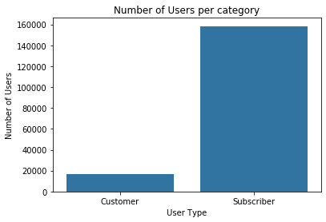

```python
#plotting a bar chart of comparison of customers and subscribers
color = sb.color_palette()[0]
sb.countplot(data = ford_copy,x = 'user_type',color = color)
plt.title('Number of Users per category')
plt.xlabel('User Type')
plt.ylabel('Number of Users');
```

# Observations

From the plot,it's obvious that there were more of subscribers than customers in february 2019 which is a really great deal for the bike sharing system.

# Question

- Is there a difference between the genders of users that rented bikes in february 2019?

# Visualization

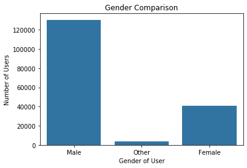

```python
#plotting a bar plot that shows comparison of gender counts for trips in feb 2019
sb.countplot(data = ford_copy,x = 'member_gender',color = color)
plt.title('Gender Comparison')
plt.xlabel('Gender of User')
plt.ylabel('Number of Users');
```

# Observations

From the plot,we can see that more males rented bikes than other genders.

# Question

- Is there a difference between the number of users that rented bikes in february 2019 per day?

# Visualization

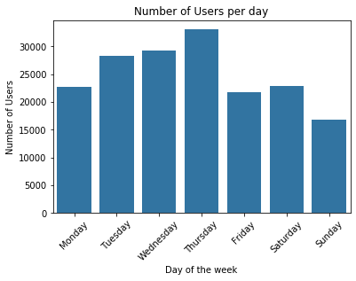

```python
#plotting a bar plot for comparison of user counts per day
sb.countplot(data = ford_copy,x = 'day',color = color)
plt.xticks(rotation = 45)
plt.title('Number of Users per day')
plt.xlabel('Day of the week')
plt.ylabel('Number of Users');
```

# Observations

- It is obvious that the bike sharing system has more bike users on thursdays and even on weekdays in general

# Question

- What is the range of trip duration for most users in the bike sharing system?

# Visualization

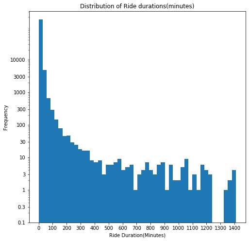

```python
#plotting a histogram to show the distribution of trip duration in feb 2019
plt.figure(figsize = (8,8))
xtick = np.arange(0,ford_copy['trip_duration_in_minutes'].max(),100)
ytick = [0.1,0.3,1,3,10,30,100,300,1000,3000,10000]
plt.hist(x = ford_copy['trip_duration_in_minutes'],bins = 50,log = True)
plt.title('Distribution of Ride durations(minutes)')
plt.xlabel('Ride Duration(Minutes)')
plt.ylabel('Frequency');
plt.xticks(xtick,xtick)
plt.yticks(ytick,ytick);
```

# Observations

1. The distribution of the ride durations is very much rightly skewed i.e it doesn't follow a normal distribution
2. Most bike users spend between 0 and 100 minutes while taking a ride with the bikes.
3. There are also outliers in the ride durations roughly between 1300 minutes and 1400 minutes

# Question

- What is the range of ages of users that participate in the bike sharing system in feb 2019?

# Visualization

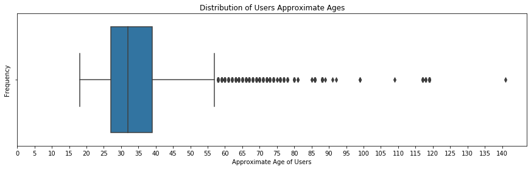

```python
#plotting a boxplot to show the distribution of user ages
plt.figure(figsize = (15,4))
xtick = np.arange(0,ford_copy['member_approximate_age'].max(),5)
sb.boxplot(x = ford_copy['member_approximate_age'])
plt.xticks(xtick,xtick)
plt.title('Distribution of Users Approximate Ages')
plt.xlabel('Approximate Age of Users')
plt.ylabel('Frequency');
```

# Observations

1. These are alot of outliers according to the plot above
2. Most users are between the ages of 25 and 40

### Discuss the distribution(s) of your variable(s) of interest. Were there any unusual points? Did you need to perform any transformations?

> From the univariate plot on the user type comparison ,it was obvious that there were more of subscribers than customers in february 2019 which is a really great deal for the bike sharing system. As the name implies subscribers are long-term cutsomers of a business (active or not). With the difference between the numnber of subscribers and number of customers,it shows how much users find the bike sharing system beneficial in terms of long and short distance movements.

# Question

- What is the difference between the trip duration of subscribers and trip duration of customers?